# Lab01_CDP - Análise de Gastos de Deputados: Nossas Perguntas

José Ivan

3 de setembro de 2018

```r
library(tidyverse)
```

Para iniciarmos nossa análise, o primeiro passo é importar os dados do csv para um dada frame.

```r
dados <- read_csv(("dadosCEAP.csv"))
limiteCEAP <- read_csv(("limiteMensalCEAP.csv"))
limiteCEAP <- limiteCEAP %>%  rename(sgUF = UF)
dados <- full_join(dados, limiteCEAP, by = "sgUF")
```

Para encontramos os deputados que menos e mais gastaram recursos da CEAP, filtramos os valores liquidos maiores que zero (para que as compensações não afetem no resultado final), agrupamos cada deputado pelo seu nome e somamos os seus gastos.

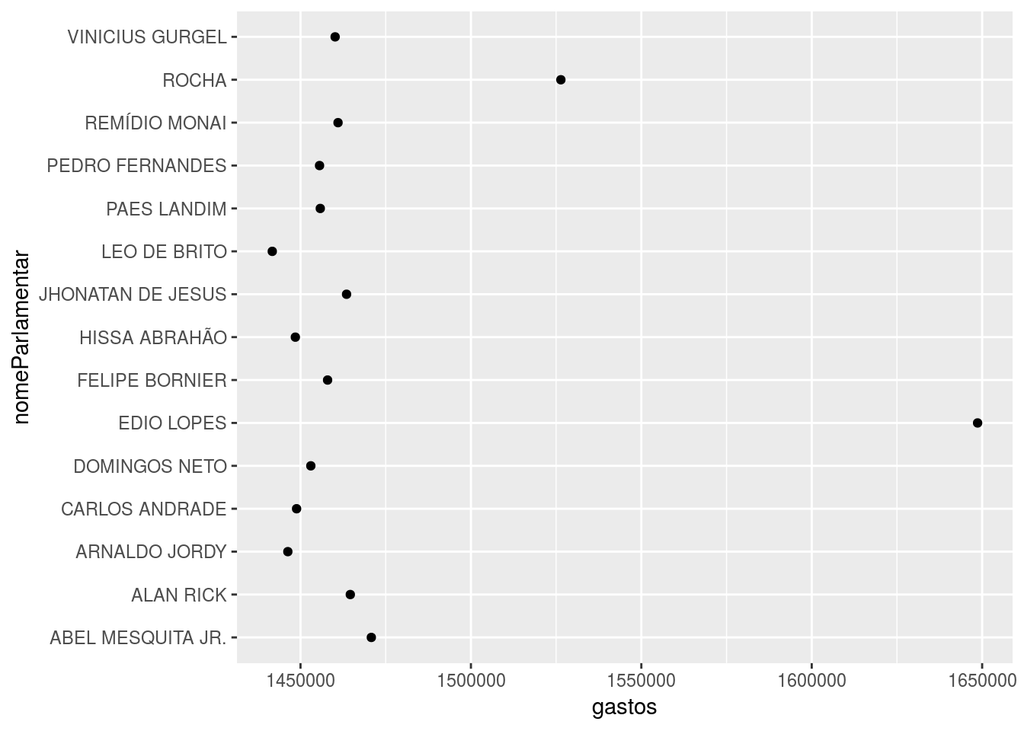

```r
#1 a)

 # filtra-se os valores liquidos maiores que zero, em seguida os deputados sao agrupados por nome e seus gastos sao somados. Seleciona-se os 15 que mais gastaram.

 dados %>%
   filter(valorLíquido > 0) %>%
   group_by(nomeParlamentar) %>% summarise(gastos = sum(valorLíquido)) %>% top_n(15) %>%
   ggplot(aes(x = gastos, y = nomeParlamentar)) +
  geom_point()
```

Utilizamos a função top_n para obtermos os 15 deputados que mais gastaram. Podemos ver, pelo gráfico, que os deputados Edio Lopes, Rocha e Abel Mesquita Jr foram os que mais gastaram, respectivamente. O restante dos 15, podem ser visto no gráfico.

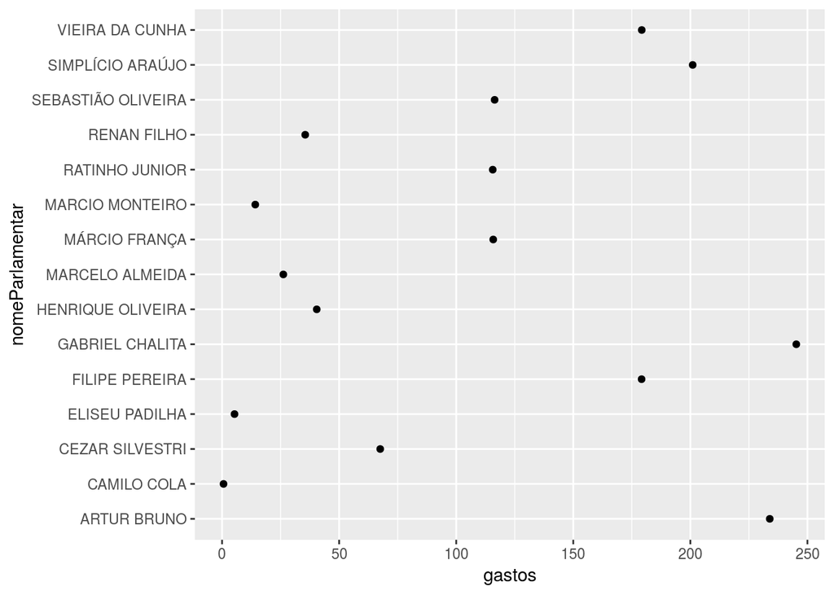

```r
#1 b)

# filtra-se os valores liquidos maiores que zero, em seguida os deputados sao agrupados por nome e seus gastos sao somados. Seleciona-se os 15 que menos gastaram.

dados %>%
   filter(valorLíquido > 0) %>%
   group_by(nomeParlamentar) %>% summarise(gastos = sum(valorLíquido)) %>% top_n(-15) %>%
   ggplot(aes(x = gastos, y = nomeParlamentar)) +
  geom_point()
```

No item 2, para acharmos os estados nos quais seus deputados gastam mais no exterior, filtramos os dados pelo tipo de documento 2 (documento que indica gasto no exterior) e os valores liquidos maiores que zero (para que as compensações não afetem no resultado final), agrupamos os dados por estados e somamos os gastos dos deputados.

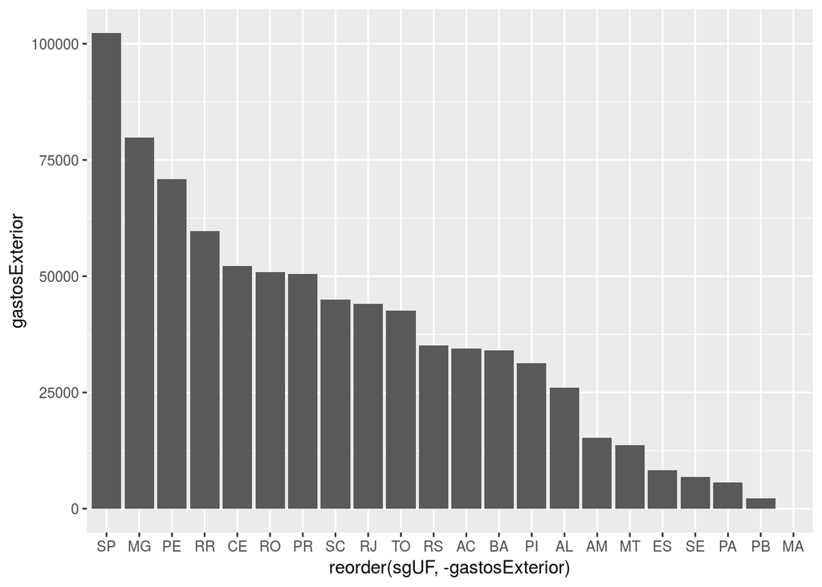

```r
#2 a)

 # Para pegarmos os gastos no exterior, filtramos pelo tipo de documento 2. Filtramos os valores liquidos maiores que zero e agrupamos por estado. Em seguida, somamos os gastos correspondentes, que correspondem aos gatos no exterior.

 dados %>%
  filter(tipoDocumento == 2 & valorLíquido > 0) %>%
  group_by(sgUF) %>% summarise(gastosExterior = sum(valorLíquido)) %>%
  ggplot(aes(x = reorder(sgUF, -gastosExterior), y = gastosExterior)) + geom_bar(stat = "identity")
```

Como podemos enxergar no gráfico, os três estados onde seus deputados mais gastam no exterior é São Paulo, Minas Gerais e Pernambuco. Os três que menos gastam são Maranhão, Paraíba e Pará. O restante do ranking pode ser visto no gráfico.

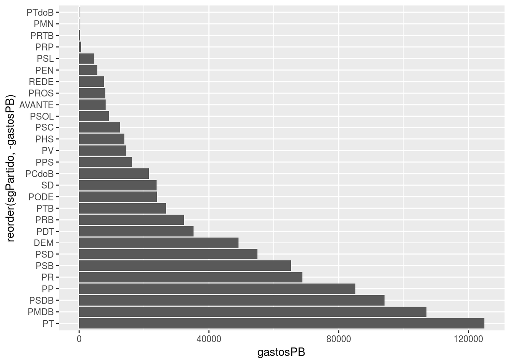

```r
 # Filtramos os gastos maiores que zero, agrupamos pelo estado da Paraíba e pelos partidos. Em seguida, somamos a quantidade de despesa que cada partido gerou.

 dados  %>%
  filter(valorLíquido > 0)  %>%
  group_by(sgUF = "PB")  %>%
  group_by(sgPartido)  %>%
  summarise(gastosPB = n()) %>%
  na.omit() %>%
  ggplot(aes(x = reorder(sgPartido, -gastosPB), y = gastosPB)) + geom_bar(stat = "identity") + coord_flip()
```

Agora, para calcular o valor, fazemos o mesmo procedimento para emcontrar a quantidade, porém, ao invés de somarmos as quantidades, somamos os valores.

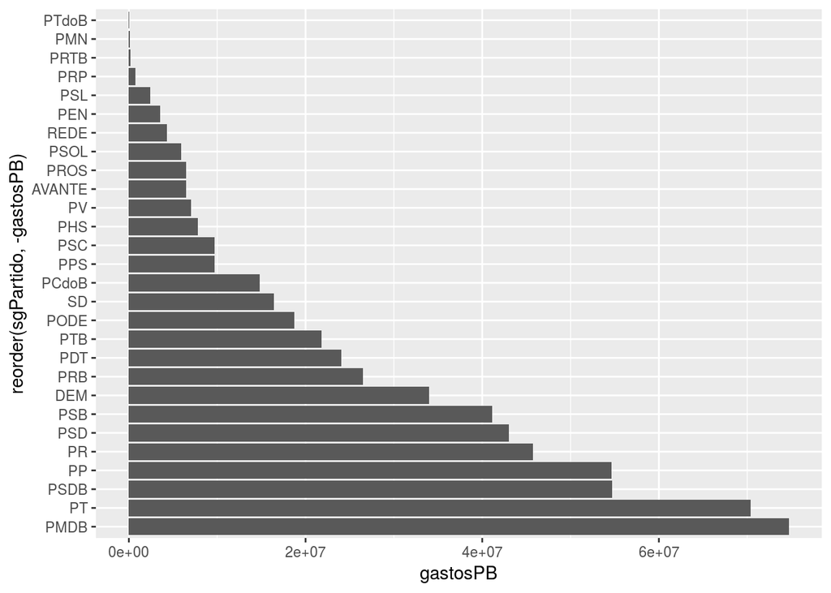

```r
# Filtramos os gastos maiores que zero, agrupamos pelo estado da Paraíba e pelos partidos. Em seguida, somamos o valor da despesa que cada partido gerou.

  dados %>%
  filter(valorLíquido > 0) %>%
  group_by(sgUF = "PB") %>%
  group_by(sgPartido) %>%
  summarise(gastosPB = sum(valorLíquido)) %>%
  na.omit() %>%
  ggplot(aes(x = reorder(sgPartido, - gastosPB), y = gastosPB)) + geom_bar(stat = "identity") + coord_flip()
```

Para encontrar os deputados que mais ultrapassaram os limites de seu estados, agrupamos os mesmos por nome e limite mensal, somamos seus gastos e depois filtramos aqueles que ultrapassaram o limite.

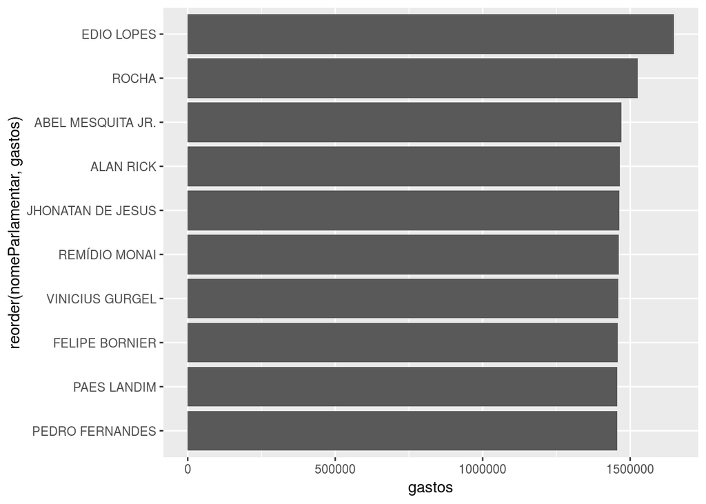

```r
#4
# Filtra-se os valores liquidos maiores que zero, agrupa-se os parlamentares por nome e pelo limite de gasto mensal de cada estado , em seguida, soma-se os gastos totais de cada um filtra-se aqueles que ultrapassam o limite, deixando-os de forma ordenada em relacao aos gastos.
 dados %>%
 filter(valorLíquido > 0) %>%
 group_by(nomeParlamentar, limite_mensal) %>%
 summarise(gastos = sum(valorLíquido)) %>%
 filter(gastos > limite_mensal) %>%
 arrange(desc(gastos)) %>%
 head(10) %>%
 ggplot(aes(x = reorder(nomeParlamentar, gastos), y = gastos)) + geom_bar(stat = "identity") + coord_flip()
```

Podemos ver pelo gráfico que os trẽs deputados que mais ultrapassaram o limite de seu estados foram Edio Lopes, Rocha e Abel Mesquita Jr. O restante (top 10) podemos ver no gráfico.

Para acharmos os estados que os parlamentares mais gastam em passagens aéreas, filtramos o tipo da despesa como despesa aérea, agrupamos os estados e somamos os gastos em passagem. Assim teremos os gastos com passagens aéreas por cada estado.

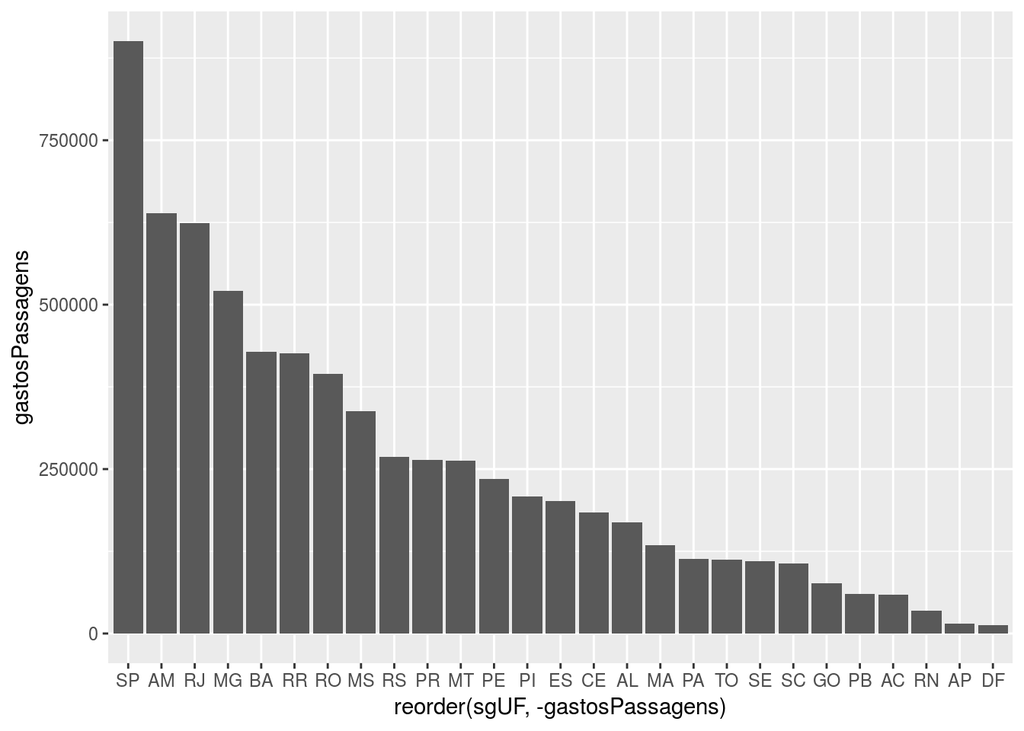

```r
#5
  # os dados sao filtrados pelo tipo de passagens aereas, em seguida, os estados sao agrupados e somados os gastos liquidos correspondentes.

  dados %>%
  filter(tipoDespesa == "PASSAGENS AÉREAS") %>% group_by(sgUF)  %>% summarise(gastosPassagens = sum(valorLíquido)) %>%
  na.omit() %>%
  ggplot(aes(x = reorder(sgUF, -gastosPassagens), y = gastosPassagens)) + geom_bar(stat = "identity")
```

Como podemos ver no gráfico, os três estados que mais gastam com passagens aéreas são São Paulo, Amazonas e Rio de Janeiro. O restante do ranking podemos ver pelo gráfico.

No item 6, os partidos escolhidos foram PT, PMDB e DEM. Primeiro filtramos esses partidos no conjunto de partidos que temos no dataframe, depois agrupamos os tipos de despesa e somamos a quantidade de cada um.

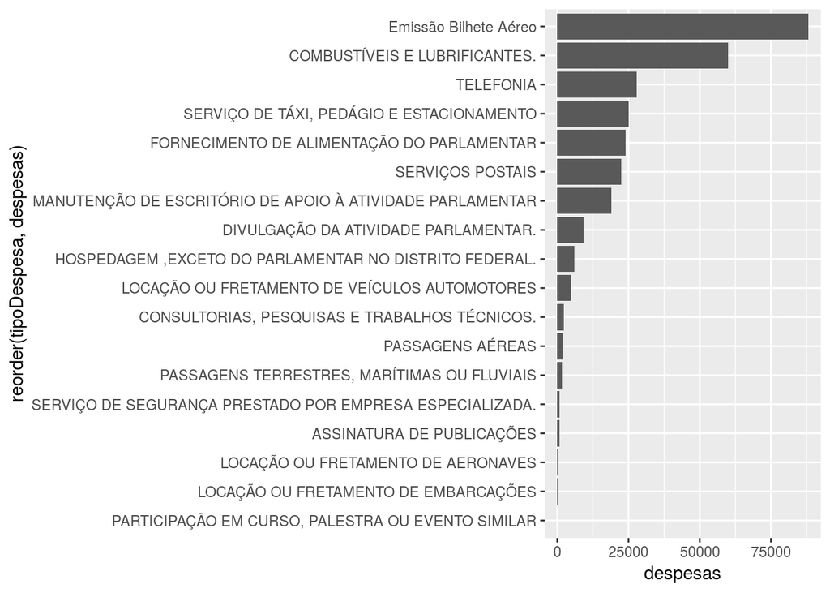

```r
#6 a)

# primeiro, foi criado um array com três partidos escolhidos, logo depois os mesmos são filtrados no dataframe
# em seguida, agrupa-se a variável tipoDespesa e soma-se os quantidade de vezes de menção a cada tipo de gasto.

partidos <- c("PT", "PMDB", "DEM")

dados %>% filter(sgPartido %in% partidos) %>%
group_by(tipoDespesa) %>%
summarise(despesas = n()) %>%
ggplot(aes(x = reorder(tipoDespesa, despesas), y = despesas)) + geom_bar(stat = "identity") + coord_flip()
```

Como podemos ver, o tipo de despesa mais popular é a emissão de bilhete aéreo, provavelmente pelo fato da maioria dos deputados não morarem em Brasília e precisarem se deslocar de seus estados para o Distrito Federal. Outras despesas populares são combusíveis e lubrificantes e telefonia, na ordem. O restante dos gastos maos populares podem ser visto nos gráficos.

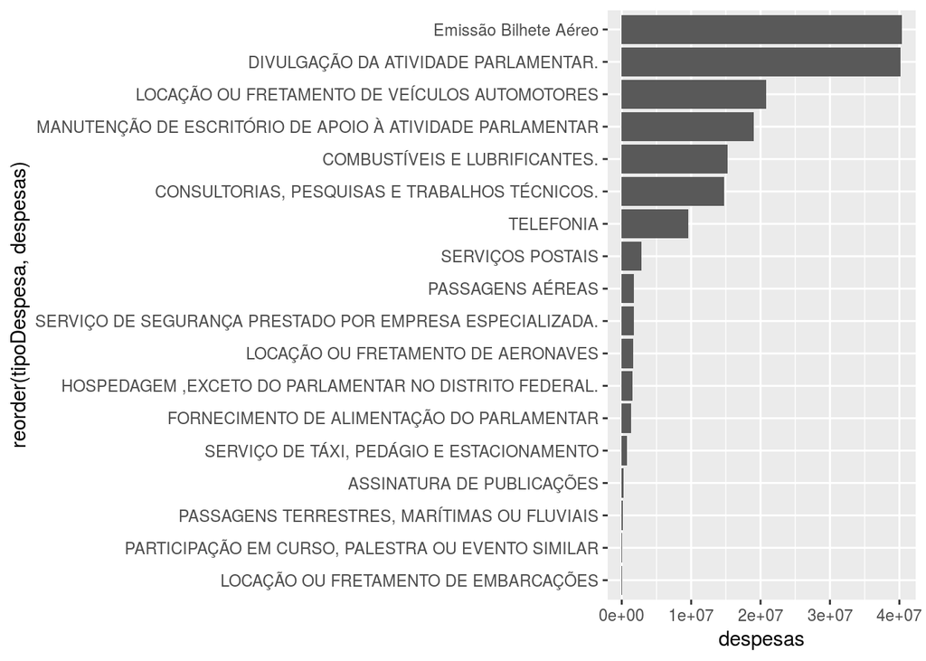

```r
# primeiro, foi criado um array com três partidos escolhidos, logo depois os mesmos são filtrados no dataframe
# em seguida, agrupa-se a variável tipoDespesa e soma-se os gastos liquidos correspondentes.

partidos <- c("PT", "PMDB", "DEM")

dados %>% filter(sgPartido %in% partidos) %>%
group_by(tipoDespesa) %>%
summarise(despesas = sum(valorLíquido)) %>%
ggplot(aes(x = reorder(tipoDespesa, despesas), y = despesas)) + geom_bar(stat = "identity") + coord_flip()
```

Analisando agora os gastos mais populares em termos de valores, vemos que a emissão de bilheres aéreos ainda ocupa o topo, pelos menos motivos já apresentadps acima. Divulgação da atividade parlamentar e locação ou fretamento de veículos automotores são outros também populares, na ordem.